# Análise precisão e recall

Aline Costa

1 de julho de 2019

```r
execucao = read_csv(here::here("data/execucao_daikon.csv"))
invariantes = read_csv(here::here("data/invariantes_corretos.csv"))
glimpse(invariantes)
```

```
## Observations: 78
## Variables: 5
## $ classe <chr> "atm", "atm", "atm", "atm", "atm", "atm", "Transaction"...
## $ nJEs   <dbl> 24, 24, 24, 24, 24, 24, 13, 13, 13, 13, 13, 13, 10, 10,...
## $ delph  <dbl> 0, 1, 2, 0, 1, 2, 0, 1, 2, 0, 1, 2, 0, 1, 2, 0, 1, 2, 0...
## $ std    <dbl> 0, 0, 0, 1, 1, 1, 0, 0, 0, 1, 1, 1, 0, 0, 0, 1, 1, 1, 0...
## $ nLIs   <dbl> 13, 13, 13, 13, 13, 13, 5, 5, 4, 4, 4, 4, 6, 6, 5, 5, 6...
```

```r
glimpse(execucao)
```

```
## Observations: 78
## Variables: 5
## $ classe <chr> "atm", "atm", "atm", "atm", "atm", "atm", "Transaction"...
## $ nJEs   <dbl> 24, 24, 24, 24, 24, 24, 13, 13, 13, 13, 13, 13, 10, 10,...
## $ delph  <dbl> 0, 1, 2, 0, 1, 2, 0, 1, 2, 0, 1, 2, 0, 1, 2, 0, 1, 2, 0...
## $ std    <dbl> 0, 0, 0, 1, 1, 1, 0, 0, 0, 1, 1, 1, 0, 0, 0, 1, 1, 1, 0...
## $ nLIs   <dbl> 6489, 6376, 245, 212, 212, 210, 4012, 1115, 27, 43, 47,...
```

```r
dados_completos = read_csv(here::here("data/dados_completos.csv"))
glimpse(dados_completos)
```

```
## Observations: 78
## Variables: 6
## $ classe       <chr> "atm", "atm", "atm", "atm", "atm", "atm", "Transa...
## $ nJEs         <dbl> 24, 24, 24, 24, 24, 24, 13, 13, 13, 13, 13, 13, 1...
## $ delph        <dbl> 0, 1, 2, 0, 1, 2, 0, 1, 2, 0, 1, 2, 0, 1, 2, 0, 1...
## $ std          <dbl> 0, 0, 0, 1, 1, 1, 0, 0, 0, 1, 1, 1, 0, 0, 0, 1, 1...
## $ nLIs         <dbl> 6489, 6376, 245, 212, 212, 210, 4012, 1115, 27, 4...
## $ nLIscorretos <dbl> 13, 13, 13, 13, 13, 13, 5, 5, 4, 4, 4, 4, 6, 6, 5...
```

Para calcular a quantidade de elementos nos conjuntos B, C e D utilizamos as definições: B é o conjunto de invariantes especificado inicialmente no sistema ATM. Correspondente a coluna nJEs C é o conjunto de prováveis invariantes relatados pela Daikon. Correspondente a coluna nLIs D é a interseção entre C e B. Correspondente a coluna nLIscorretos

Precisamos para cada configuração (–nesting-depth, com os valores 0, 1 e 2 e –std-visibility, verdadeiro e falso), calcular B, C e D.

```r
dados_completos_por_configuracao <- dados_completos %>%
  group_by(delph, std) %>%
  summarise(b = sum(nJEs), c = sum(nLIs), d = sum(nLIscorretos))
```

Agora podemos calcular precisão e recall de acordo com nossas fórmulas Precisão = número de identificações corretas / número total de expressões relatadas; Recall = número de identificações corretas / número total de contratos especificados pelos projetistas;

```r
dados_completos_por_configuracao <- dados_completos_por_configuracao %>%
  mutate(precisao = (d / c), recall = (d / b))
```

Plotando os valores em uma visualização para destacar os padrões mencionados na análise.

# passando variáveis como factor para aplicar o shape

```r
dados_completos_por_configuracao$delph <- factor(dados_completos_por_configuracao$delph)
dados_completos_por_configuracao$std <- factor(dados_completos_por_configuracao$std)
```

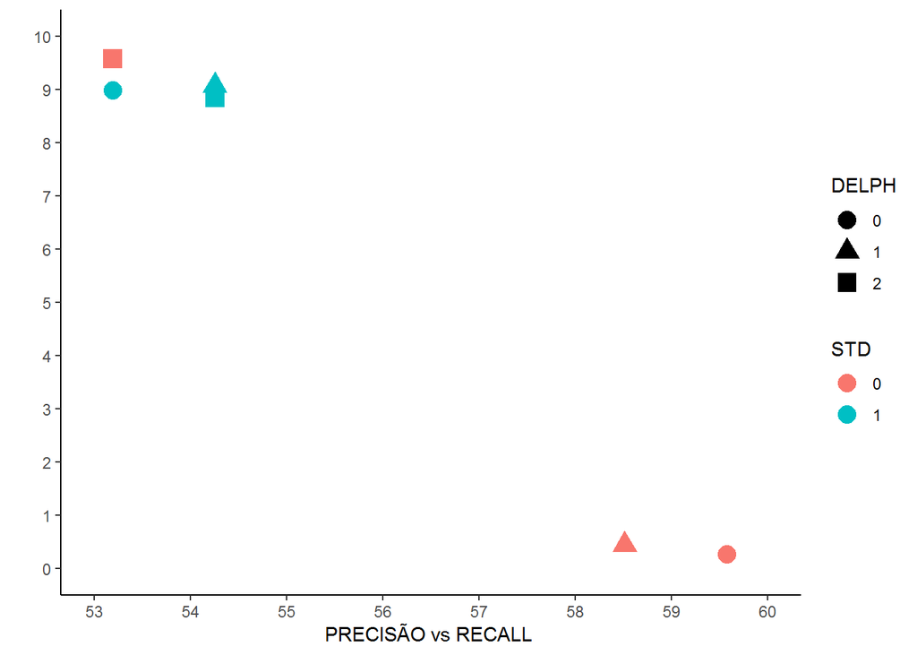

```r
ggplot(aes(x = recall*100, y = precisao*100, shape = delph),
       data = dados_completos_por_configuracao) +
  geom_point(mapping = aes(color = std), size = 4.5) +
  labs(x = "PRECISÃO vs RECALL ",
       y = " ",
       colour = "STD",
       shape = "DELPH") +
  scale_x_continuous(limits = c(53, 60), breaks = seq(53, 60, 1)) +
  scale_y_continuous(limits = c(0, 10), breaks = seq(0, 10, 1)) +
  theme_classic()
```

A visualização evidencia algumas observações interessantes do nosso estudo de caso. Como mencionado na análise, quando o parâmetro std-visibility (STD) é 0 (false), a ferramenta Daikon apresenta um recall mais alto, ou seja, ele consegue inferir mais invariantes corretas do que com std-visibility igual a 1. A exceção foi quando o parâmetro –nesting-depth (DELPH) foi setado para 2. Neste caso, a Daikon provavelmente se perdeu na maior profundidade da classes e atributos que deveria analisar e acabau perdendo alguns invariantes corretos. Esta observação, evidenciada pela análise, corrobora os resultados do artigo original.